# Kristen_Assignment1

## Part 6

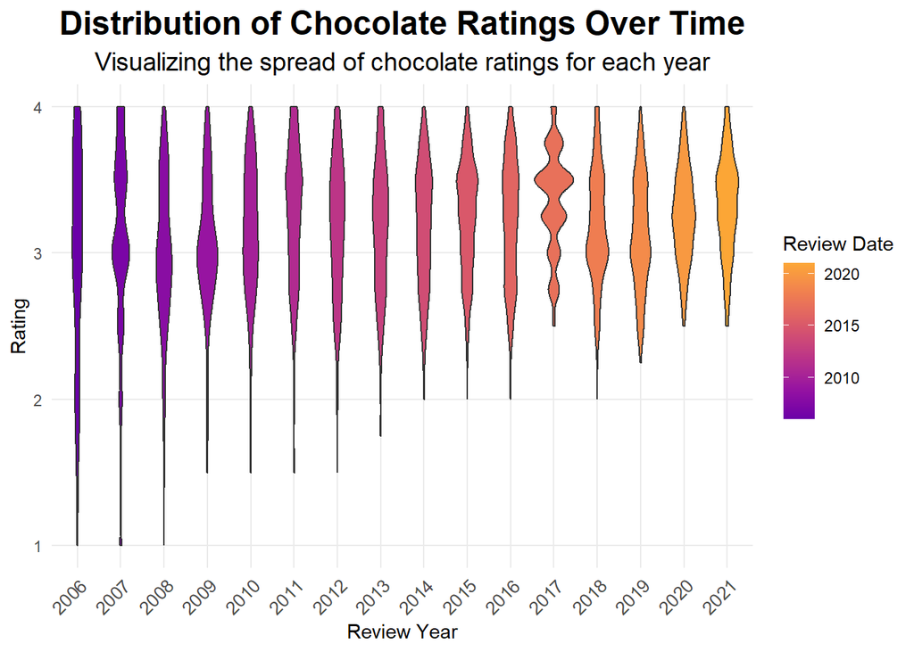

```r
ggplot(chocolate, aes(x = as.factor(review_date), y = rating, fill = review_date)) +
  geom_violin() +

  # 1. add topic
  labs(
    title = "Distribution of Chocolate Ratings Over Time",
    subtitle = "Visualizing the spread of chocolate ratings for each year",
    x = "Review Year",  # 2. x
    y = "Rating",       # 3. y
    fill = "Review Date"  # 4. topic
  ) +

  # 5. clear color
  scale_fill_viridis_c(option = "C", begin = 0.2, end = 0.8) +

  # 6. font
  theme_minimal() +
  theme(
    plot.title = element_text(size = 18, face = "bold", hjust = 0.5),  #
    plot.subtitle = element_text(size = 14, hjust = 0.5),  #
    axis.text.x = element_text(angle = 45, hjust = 1, size = 10),  #
    legend.position = "right",  # 7. right
    panel.grid.minor = element_blank()
  )
```

**1. Add title and subtitle**

**2. Add x-axis label**

**3. Add y-axis label**

**4. Add a title for the legend**

**5. Optimize the color scheme: Use a color gradient to make the distinction between different years more apparent**

**6. Adjust x-axis labels: Rotate and shrink the font of the x-axis labels to avoid overlapping**

**7. Adjust the legend position: Place the legend on the right**

**8. Remove minor gridlines to reduce visual distractions**